# Clustering Heart Disease Patient Data

Jose A Maldonado-Garcia

3/26/2020

## Targeting Treatment for Heart Disease Patients

Unsupervised clustering algorithms allow us to group patients on their shared similar characteristics. This will help doctors understand which treatments might work their patients.

```
##   id age sex cp trestbps chol fbs restecg thalach exang oldpeak slope
## 1  1  63   1  1      145  233   1       2     150     0     2.3     3
## 2  2  67   1  4      160  286   0       2     108     1     1.5     2
## 3  3  67   1  4      120  229   0       2     129     1     2.6     2
## 4  4  37   1  3      130  250   0       0     187     0     3.5     3
## 5  5  41   0  2      130  204   0       2     172     0     1.4     1
## 6  6  56   1  2      120  236   0       0     178     0     0.8     1
```

Before grouping patients, we will conduct some basic summary statistics to familiarize ourselves with the data and to determine if scaling the data is needed.

```
##        id             age             sex               cp
##  Min.   :  1.0   Min.   :29.00   Min.   :0.0000   Min.   :1.000
##  1st Qu.: 76.5   1st Qu.:48.00   1st Qu.:0.0000   1st Qu.:3.000
##  Median :152.0   Median :56.00   Median :1.0000   Median :3.000
##  Mean   :152.0   Mean   :54.44   Mean   :0.6799   Mean   :3.158
##  3rd Qu.:227.5   3rd Qu.:61.00   3rd Qu.:1.0000   3rd Qu.:4.000
##  Max.   :303.0   Max.   :77.00   Max.   :1.0000   Max.   :4.000
##     trestbps          chol            fbs            restecg
##  Min.   : 94.0   Min.   :126.0   Min.   :0.0000   Min.   :0.0000
##  1st Qu.:120.0   1st Qu.:211.0   1st Qu.:0.0000   1st Qu.:0.0000
##  Median :130.0   Median :241.0   Median :0.0000   Median :1.0000
##  Mean   :131.7   Mean   :246.7   Mean   :0.1485   Mean   :0.9901
##  3rd Qu.:140.0   3rd Qu.:275.0   3rd Qu.:0.0000   3rd Qu.:2.0000
##  Max.   :200.0   Max.   :564.0   Max.   :1.0000   Max.   :2.0000
##     thalach          exang           oldpeak         slope
##  Min.   : 71.0   Min.   :0.0000   Min.   :0.00   Min.   :1.000
##  1st Qu.:133.5   1st Qu.:0.0000   1st Qu.:0.00   1st Qu.:1.000
##  Median :153.0   Median :0.0000   Median :0.80   Median :2.000
##  Mean   :149.6   Mean   :0.3267   Mean   :1.04   Mean   :1.601
##  3rd Qu.:166.0   3rd Qu.:1.0000   3rd Qu.:1.60   3rd Qu.:2.000
##  Max.   :202.0   Max.   :1.0000   Max.   :6.20   Max.   :3.000
```

Now we can proceed with clustering our data.

## K-means Clustering

To ensure the K-means is clustering similar observations, as opposed to clustering noise, we will run the algorithms twice. If patients are not in similar clusters after different iterations, then the clustering method is not picking up on meaningful relationships between patients.

The following is the grouping for the first K-means run:

```
## [1] 66 43 88 61 45
```

The following is the grouping for the second K-means run:

```
## [1] 65 43 61 46 88
```

The clusters from different iterations may not be the same but should be roughly the same size and have similar distributions of variables. If we had patients labeling, cluster validation would be possible. Since we do not have patient labeling, we’ll use graphs to see how certain patient characteristics may have been used to group patients together.

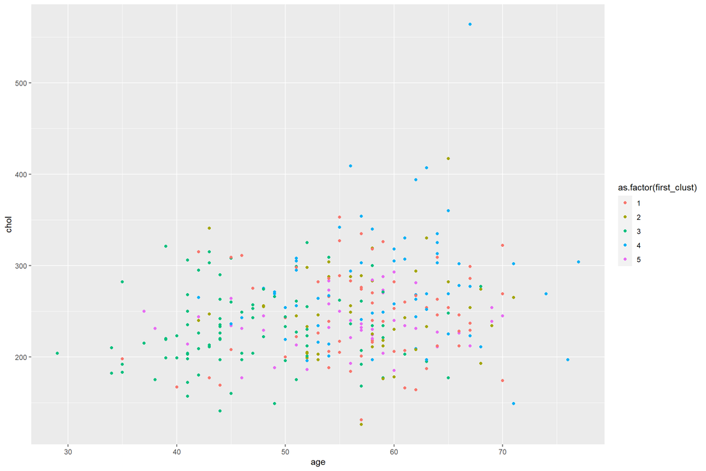

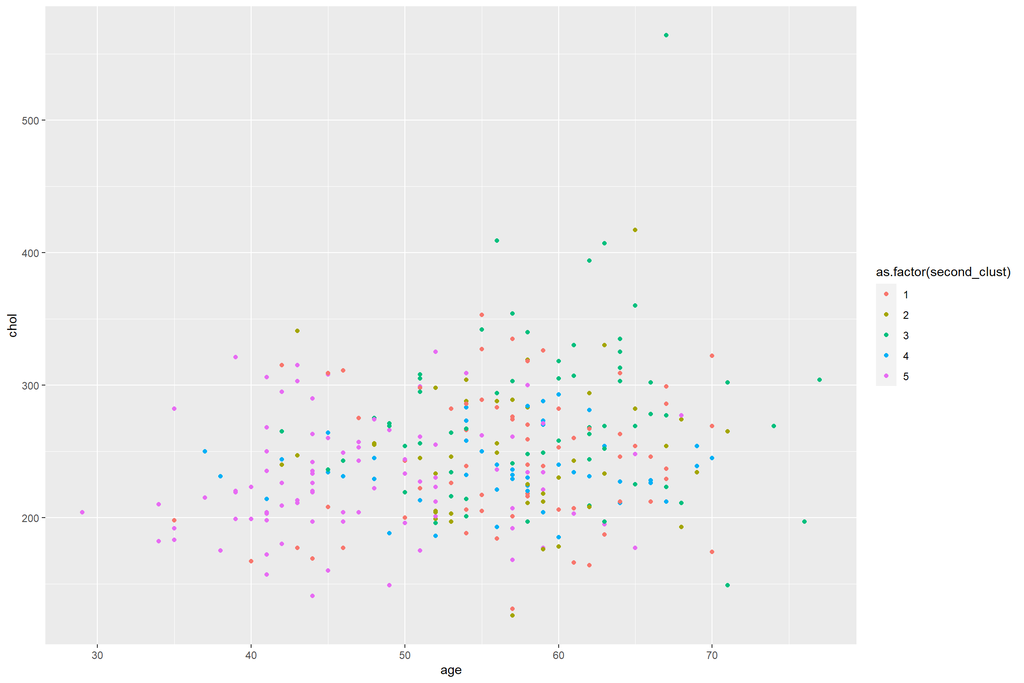

## Hierarchical Clustering

An alternative to k-means clustering is hierarchical clustering. This method works well when data have a nested structure. Heart disease patient data might follow this type of structure.

Here we’ll examine dendrograms of complete and single linkage.

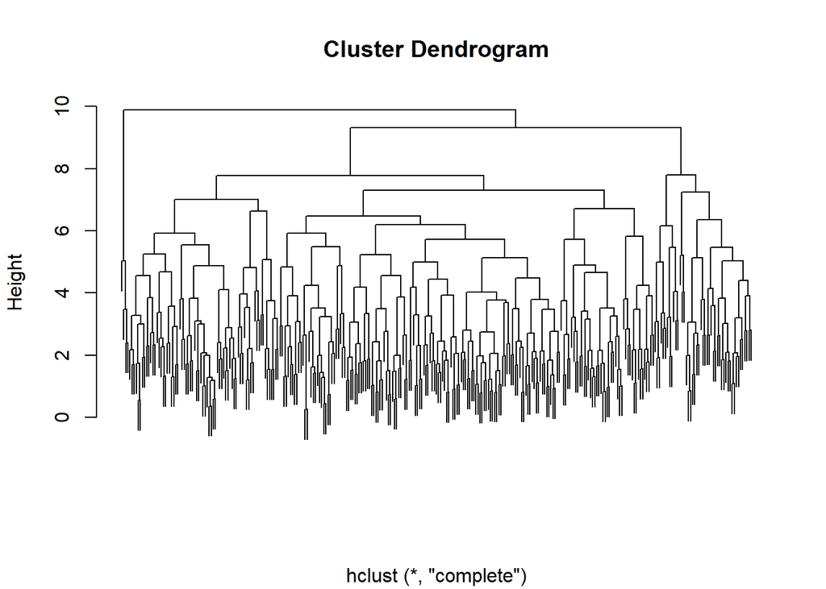

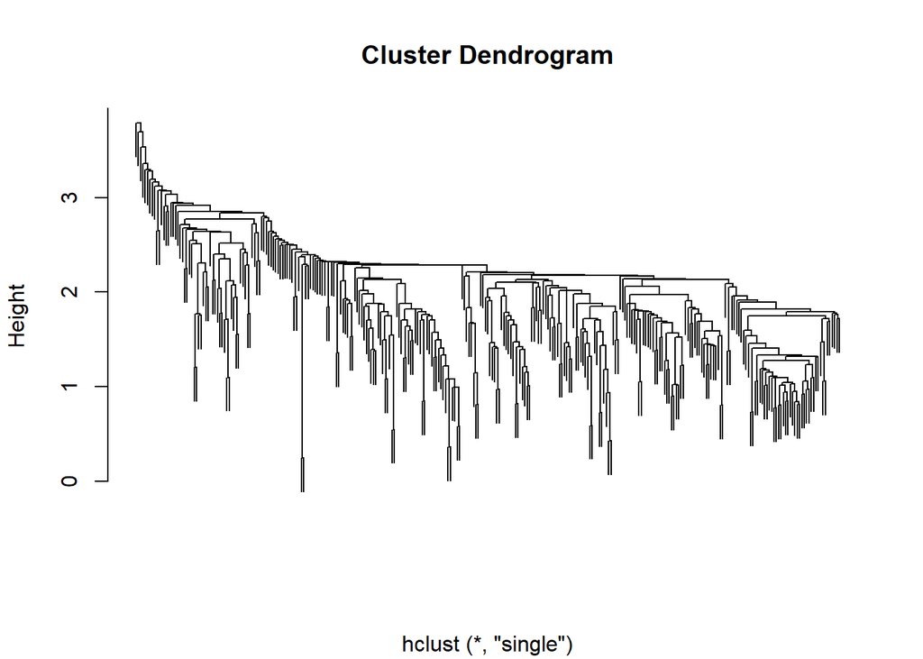

Complete linkage provides a balanced tree and will the grouping of choice. Lets examine the summary statistics created by grouping.

```
##   hc_clust  age.avg   age.sd   cp.avg     cp.sd trestbps.avg trestbps.sd
## 1        1 51.41667 8.540979 2.783333 0.9470625     129.1389    15.93800
## 2        2 58.11111 7.754246 3.763889 0.6165112     130.0417    13.90657
## 3        3 61.00000 3.908034 3.916667 0.2886751     168.5000    17.45904
## 4        4 59.00000 9.203580 3.571429 0.8501112     134.7714    18.64070
## 5        5 64.75000 2.061553 3.250000 0.5000000     138.7500    18.42779
##   chol.avg  chol.sd   fbs.avg    fbs.sd restecg.avg restecg.sd thalach.avg
## 1 239.8722 42.29228 0.1222222 0.3284559   0.8444444  0.9905826    161.5722
## 2 253.2222 49.74476 0.1805556 0.3873488   1.4027778  0.9140488    135.5417
## 3 284.9167 53.00336 0.3333333 0.4923660   1.2500000  0.9653073    147.7500
## 4 233.8571 49.67136 0.1428571 0.3550358   0.6857143  0.9321521    116.8857
## 5 433.7500 89.93470 0.2500000 0.5000000   2.0000000  0.0000000    156.2500
##   thalach.sd  exang.avg  exang.sd oldpeak.avg oldpeak.sd slope.avg  slope.sd
## 1  15.779214 0.07777778 0.2685686    0.555000  0.7847196  1.388889 0.5730336
## 2  17.991342 0.81944444 0.3873488    1.451389  1.0804268  1.750000 0.5240686
## 3  13.157266 0.75000000 0.4522670    2.316667  1.4708274  2.166667 0.5773503
## 4  17.842071 0.48571429 0.5070926    2.240000  1.3856831  2.200000 0.4058397
## 5   3.774917 0.00000000 0.0000000    1.100000  0.3829708  1.500000 0.5773503
```